# DATA TRANSFORMATION

Pascal Nguyen pn2320; Chloe Jiang hj2506; Boyan He bh2709; Anqi Yang ay2438; Yuhan Yang yy2909; Yuxi Yuan yy2927; Yilun Feng yf2489, Shengyao Li sl4481

11/9/2019

## Sections

- I.Dataset Exploration
- II.Data Preparation
- III.Data Purpose

## I. Dataset Exploration

Data Structure

```r
#data1 = px_last factors (macro_ind)
str(data1)
```

```
## 'data.frame':   6030 obs. of  37 variables:
##  $ Date               : Date, format: "1999-01-04" "1999-01-05" ...
##  $ SPLPEQTY.Index     : Factor w/ 3355 levels "","100.01","100.06",..: 1 1 1 1 1 1 1 1 1 1 ...
##  $ ECRI               : num  NA NA NA NA NA NA NA NA NA NA ...
##  $ EUSWIT2.CMPN.Curncy: num  NA NA NA NA NA NA NA NA NA NA ...
##  $ Slope.CL           : num  NA NA NA NA NA NA NA NA NA NA ...
##  $ BE.2Y.CL           : num  NA NA NA NA NA NA NA NA NA NA ...
##  $ Slope.US           : num  0.33 0.29 0.37 0.37 0.39 ...
##  $ Slope.EU           : num  NA NA NA NA NA NA NA NA NA NA ...
##  $ X0016639.Index     : num  NA NA NA NA NA NA NA NA NA NA ...
##  $ X1116639.Index     : num  NA NA NA NA NA NA NA NA NA NA ...
##  $ X1706639.Index     : num  NA NA NA NA NA NA NA NA NA NA ...
##  $ X2286639.Index     : num  NA NA NA NA NA NA NA NA NA NA ...
##  $ X9246R004.Index    : num  NA NA NA NA NA NA NA NA NA NA ...
##  $ BCMPGLGD.Index     : num  NA NA NA NA NA NA NA NA NA NA ...
```

[output cut: 23 more lines]

```r
summary(data1)
```

```
##       Date            SPLPEQTY.Index      ECRI       EUSWIT2.CMPN.Curncy
##  Min.   :1999-01-04          :1929   Min.   :105.5   Min.   :-0.085
##  1st Qu.:2004-09-02   120.88 :   5   1st Qu.:124.4   1st Qu.: 1.081
##  Median :2010-05-06   124.01 :   5   Median :131.2   Median : 1.590
##  Mean   :2010-01-02   124.54 :   5   Mean   :131.0   Mean   : 1.589
##  3rd Qu.:2015-07-03   125.63 :   5   3rd Qu.:136.6   3rd Qu.: 2.184
##  Max.   :2019-08-22   109.97 :   4   Max.   :152.7   Max.   : 3.385
##                       (Other):4077   NA's   :5008    NA's   :2100
##     Slope.CL          BE.2Y.CL         Slope.US         Slope.EU
##  Min.   :-6.3500   Min.   :-2.775   Min.   :-0.886   Min.   :-4.5340
##  1st Qu.: 0.0000   1st Qu.: 1.657   1st Qu.: 0.217   1st Qu.: 0.2047
##  Median : 0.7500   Median : 2.650   Median : 1.053   Median : 0.9432
##  Mean   : 0.6753   Mean   : 2.211   Mean   : 1.119   Mean   : 0.8257
##  3rd Qu.: 1.2245   3rd Qu.: 2.995   3rd Qu.: 1.990   3rd Qu.: 1.2719
##  Max.   : 6.7700   Max.   : 6.800   Max.   : 2.990   Max.   : 2.1255
##  NA's   :1172      NA's   :1172                      NA's   :1484
##  X0016639.Index   X1116639.Index   X1706639.Index   X2286639.Index
##  Min.   : 64.78   Min.   : 75.35   Min.   : 23.40   Min.   : 69.98
##  1st Qu.: 78.36   1st Qu.: 85.53   1st Qu.: 58.30   1st Qu.: 80.75
##  Median : 95.50   Median : 99.04   Median : 90.46   Median : 98.68
##  Mean   : 97.60   Mean   : 97.21   Mean   : 94.25   Mean   : 98.09
##  3rd Qu.:115.95   3rd Qu.:107.68   3rd Qu.:125.46   3rd Qu.:112.98
##  Max.   :140.08   Max.   :117.47   Max.   :181.36   Max.   :131.84
##  NA's   :5790     NA's   :5784     NA's   :5790     NA's   :5784
##  X9246R004.Index  BCMPGLGD.Index     BDIY.Index       BFCIUS.Index
##  Min.   : 78.90   Min.   :-6.320   Min.   :  290.0   Min.   :-12.5640
##  1st Qu.: 84.40   1st Qu.: 3.080   1st Qu.:  982.8   1st Qu.: -0.7218
##  Median : 97.60   Median : 3.710   Median : 1477.0   Median : -0.0440
##  Mean   : 98.79   Mean   : 3.588   Mean   : 2274.5   Mean   : -0.3707
##  3rd Qu.:113.08   3rd Qu.: 4.490   3rd Qu.: 2729.0   3rd Qu.:  0.4700
##  Max.   :124.20   Max.   : 6.430   Max.   :11793.0   Max.   :  1.3740
##  NA's   :5784     NA's   :5957     NA's   :870
##  CHBCIMCE.Index  CLVIEI02.Index  CPMINDX.Index   ECRPUS.1Y.Index
##  Min.   :39.24   Min.   :0.556   Min.   :38.80   Min.   : 10.00
##  1st Qu.:44.11   1st Qu.:1.615   1st Qu.:50.20   1st Qu.: 15.00
##  Median :50.67   Median :1.967   Median :51.30   Median : 15.00
##  Mean   :50.81   Mean   :2.028   Mean   :51.83   Mean   : 18.66
##  3rd Qu.:57.25   3rd Qu.:2.439   3rd Qu.:53.30   3rd Qu.: 20.00
##  Max.   :63.04   Max.   :3.536   Max.   :59.20   Max.   :100.00
##  NA's   :5841    NA's   :5783    NA's   :5855    NA's   :5160
```

[output cut: 25 more lines]

```
##  Min.   : 69.74   Min.   : 1094   Min.   : 6485   Min.   : 9631
##  1st Qu.: 93.87   1st Qu.: 1882   1st Qu.: 9826   1st Qu.:12025
##  Median :176.62   Median : 4848   Median :12309   Median :14582
##  Mean   :180.95   Mean   : 5855   Mean   :11181   Mean   :14674
##  3rd Qu.:254.32   3rd Qu.: 9787   3rd Qu.:12987   3rd Qu.:16969
##  Max.   :298.23   Max.   :13608   Max.   :14125   Max.   :20494
##  NA's   :6010     NA's   :6010    NA's   :6010    NA's   :6010
##  WGDPWRLD.Index
##  Min.   :32529
##  1st Qu.:42584
##  Median :61978
##  Mean   :59321
##  3rd Qu.:75310
##  Max.   :85791
##  NA's   :6010
```

```r
#data2 = px_last PE
str(data2)
```

```
## 'data.frame':   73 obs. of  20 variables:
##  $ YEAR                           : Date, format: "2018-12-30" "2018-09-29" ...
##  $ PRIVATE.EQUITY                 : num  469 470 454 437 423 ...
##  $ REAL.ESTATE                    : num  431 426 416 416 404 ...
##  $ BUYOUT                         : num  657 662 642 622 602 ...
##  $ DISTRESSED.PRIVATE.EQUITY      : num  574 584 575 562 558 ...
##  $ FUNDS.OF.FUNDS                 : num  328 322 309 294 282 ...
##  $ VENTURE                        : num  134 132 127 121 117 ...
##  $ PRIVATE.CAPITAL                : num  450 450 437 423 414 ...
##  $ VENTURE.ALL.STAGE              : num  111 113 109 104 101 ...
##  $ VENTURE.EARLY.STAGE            : num  145 138 129 124 121 ...
##  $ VENTURE.EXPANSION              : num  283 279 269 255 246 ...
##  $ Buyout...Small                 : num  708 682 660 623 590 ...
##  $ Buyout...Mid                   : num  651 637 620 602 583 ...
##  $ Buyout...Large                 : num  595 592 575 557 535 ...
##  $ Buyout...Mega                  : num  727 742 719 696 679 ...
##  $ Private.Capital...Asia         : num  618 625 615 604 590 ...
##  $ Private.Capital...Europe       : num  915 912 894 865 844 ...
##  $ Private.Capital...North.America: num  421 422 407 393 384 ...
##  $ Private.Equity.excl..VC        : num  610 612 592 571 553 ...
##  $ Secondaries                    : num  596 576 555 544 526 ...
```

```r
summary(data2)
```

```
##       YEAR            PRIVATE.EQUITY   REAL.ESTATE        BUYOUT
##  Min.   :2000-12-30   Min.   : 71.3   Min.   :100.0   Min.   : 81.6
##  1st Qu.:2005-06-29   1st Qu.:106.2   1st Qu.:176.3   1st Qu.:134.9
##  Median :2009-12-30   Median :176.0   Median :225.6   Median :237.1
##  Mean   :2009-12-29   Mean   :201.0   Mean   :238.7   Mean   :268.4
##  3rd Qu.:2014-06-29   3rd Qu.:281.2   3rd Qu.:315.2   3rd Qu.:380.0
##  Max.   :2018-12-30   Max.   :469.7   Max.   :430.8   Max.   :662.1
##  DISTRESSED.PRIVATE.EQUITY FUNDS.OF.FUNDS     VENTURE
##  Min.   :100.0             Min.   : 63.6   Min.   : 41.80
##  1st Qu.:212.3             1st Qu.: 91.0   1st Qu.: 50.20
##  Median :300.9             Median :124.8   Median : 62.30
##  Mean   :321.1             Mean   :148.0   Mean   : 70.72
##  3rd Qu.:478.6             3rd Qu.:195.9   3rd Qu.: 89.80
##  Max.   :583.5             Max.   :328.4   Max.   :133.70
##  PRIVATE.CAPITAL VENTURE.ALL.STAGE VENTURE.EARLY.STAGE VENTURE.EXPANSION
##  Min.   : 78.5   Min.   : 36.70    Min.   : 44.00      Min.   : 63.5
##  1st Qu.:118.0   1st Qu.: 45.20    1st Qu.: 49.60      1st Qu.: 90.6
##  Median :190.5   Median : 53.10    Median : 63.00      Median :124.6
##  Mean   :207.7   Mean   : 61.86    Mean   : 72.09      Mean   :147.5
##  3rd Qu.:287.5   3rd Qu.: 82.50    3rd Qu.: 96.10      3rd Qu.:219.2
##  Max.   :450.0   Max.   :112.60    Max.   :145.40      Max.   :282.6
##  Buyout...Small   Buyout...Mid   Buyout...Large  Buyout...Mega
##  Min.   : 84.8   Min.   : 80.7   Min.   : 82.6   Min.   : 80.9
##  1st Qu.:126.3   1st Qu.:119.1   1st Qu.:137.3   1st Qu.:141.3
##  Median :210.8   Median :206.7   Median :225.6   Median :250.8
##  Mean   :266.3   Mean   :257.6   Mean   :254.8   Mean   :290.4
##  3rd Qu.:379.8   3rd Qu.:365.6   3rd Qu.:352.3   3rd Qu.:416.4
##  Max.   :707.6   Max.   :650.8   Max.   :594.6   Max.   :742.3
##  Private.Capital...Asia Private.Capital...Europe
##  Min.   :100.0          Min.   : 93.3
##  1st Qu.:177.1          1st Qu.:209.2
##  Median :310.0          Median :404.8
##  Mean   :310.8          Mean   :401.0
##  3rd Qu.:400.9          3rd Qu.:551.1
##  Max.   :625.1          Max.   :914.7
##  Private.Capital...North.America Private.Equity.excl..VC  Secondaries
##  Min.   : 74.9                   Min.   : 80.8           Min.   : 93.3
##  1st Qu.:109.8                   1st Qu.:130.1           1st Qu.:151.4
##  Median :171.0                   Median :225.4           Median :252.0
##  Mean   :193.2                   Mean   :254.8           Mean   :276.9
##  3rd Qu.:269.0                   3rd Qu.:361.3           3rd Qu.:405.5
##  Max.   :421.5                   Max.   :612.2           Max.   :596.5
```

```r
#data3 = Factors_data
str(data3)
```

```
## 'data.frame':   1328833 obs. of  5 variables:
##  $ X     : int  0 1 2 3 4 5 6 7 8 9 ...
##  $ campo : Factor w/ 9 levels "CUR_MKT_CAP",..: 8 6 1 4 7 5 2 3 9 8 ...
##  $ fecha : Factor w/ 7343 levels "1900-01-01","1999-01-01",..: 1 1 1 1 1 1 1 1 1 1 ...
##  $ ticker: Factor w/ 52 levels "BGCVTRUU Index",..: 37 37 37 37 37 37 37 37 37 38 ...
##  $ valor : num  -1 -1 -1 -1 -1 -1 -1 -1 -1 -1 ...
```

```r
summary(data3)
```

```
##        X                                   campo
##  Min.   :      0   PX_LAST                    :204130
##  1st Qu.: 332208   TOT_RETURN_INDEX_GROSS_DVDS:204130
##  Median : 664416   CUR_MKT_CAP                :166689
##  Mean   : 664416   DVD_SH_12M                 :163636
##  3rd Qu.: 996624   EQY_DVD_YLD_12M            :154984
##  Max.   :1328832   INDX_PX_BOOK               :149517
##                    (Other)                    :285747
##         fecha                  ticker            valor
##  2010-03-31:    277   NIFTY Index :  43296   Min.   :        -1
##  2010-06-29:    277   MXCN Index  :  43129   1st Qu.:         5
##  2010-06-30:    277   KOSPI2 Index:  42820   Median :        40
##  2010-07-02:    277   MXEF Index  :  42771   Mean   :   6298308
##  2010-07-06:    277   MXRU Index  :  42741   3rd Qu.:      1656
##  2010-07-07:    277   MXLA Index  :  42717   Max.   :1461919026
##  (Other)   :1327171   (Other)     :1071359
```

Change variable to appropriate data type

```r
data1$SPLPEQTY.Index <- as.numeric(data1$SPLPEQTY.Index)
data1$JFHIGLOB.Index <- as.numeric(data1$JFHIGLOB.Index)
```

Rename and format the common column date to merge all datasets later on

```r
colnames(data2)[colnames(data2)=="YEAR"] <- "Date"
colnames(data3)[colnames(data3)=="fecha"] <- "Date"
data3$Date = as.Date(data3$Date, "%Y-%m-%d")
data2$Date = as.Date(data2$Date, "%Y-%m-%d")
data1$Date = as.Date(data1$Date, "%Y-%m-%d")
```

Datasets are examined for missing value

```r
data1 %>%
  select(everything()) %>%
  summarise_all(funs(sum(is.na(.))))
```

```
##   Date SPLPEQTY.Index ECRI EUSWIT2.CMPN.Curncy Slope.CL BE.2Y.CL Slope.US
## 1    0              0 5008                2100     1172     1172        0
##   Slope.EU X0016639.Index X1116639.Index X1706639.Index X2286639.Index
## 1     1484           5790           5784           5790           5784
##   X9246R004.Index BCMPGLGD.Index BDIY.Index BFCIUS.Index CHBCIMCE.Index
## 1            5784           5957        870            0           5841
##   CLVIEI02.Index CPMINDX.Index ECRPUS.1Y.Index EPUCGLCP.Index
## 1           5783          5855            5160           5783
##   EUICEMU.Index GDGCAFJP.Index JFHIGLOB.Index NAPMPMI.Index NYFYPROB.Index
## 1          5783           4984              0          5783           5783
##   OECLKLAC.Index OECNKLAC.Index OEOEKLAC.Index OEOTKLAC.Index
## 1           5784           5784           5784           5784
##   OEUSKLAC.Index VIX.Index WGDPCHIL.Index WGDPCHIN.Index WGDPEURO.Index
## 1           5784       837           6010           6010           6010
##   WGDPUS.Index WGDPWRLD.Index
## 1         6010           6010
```

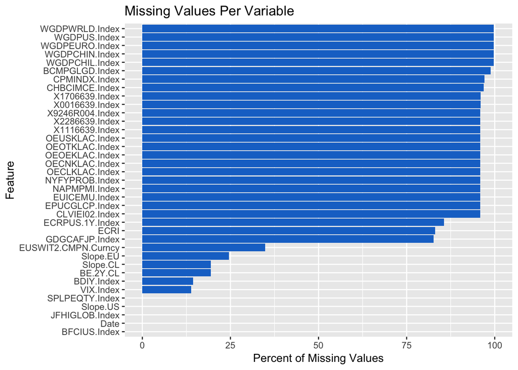

```r
#visualize missing values
missing_data = data1 %>%
  map_df(function(x) sum(is.na(x))) %>%
  gather(feature, num_nulls)%>%
  arrange(desc(num_nulls))%>%
  mutate(percent_missing = num_nulls/nrow(data1)*100)

ggplot(missing_data, aes(reorder(feature,percent_missing),percent_missing)) +geom_bar(stat = "identity", fill = "dodgerblue3")  + coord_flip() + labs(title = "Missing Values Per Variable", y = "Percent of Missing Values", x = "Feature") +scale_y_continuous(limits = c(0, 100))
```

```r
data2 %>%
  select(everything()) %>%
  summarise_all(funs(sum(is.na(.))))
```

```
##   Date PRIVATE.EQUITY REAL.ESTATE BUYOUT DISTRESSED.PRIVATE.EQUITY
## 1    0              0           0      0                         0
##   FUNDS.OF.FUNDS VENTURE PRIVATE.CAPITAL VENTURE.ALL.STAGE
## 1              0       0               0                 0
##   VENTURE.EARLY.STAGE VENTURE.EXPANSION Buyout...Small Buyout...Mid
## 1                   0                 0              0            0
##   Buyout...Large Buyout...Mega Private.Capital...Asia
## 1              0             0                      0
##   Private.Capital...Europe Private.Capital...North.America
## 1                        0                               0
##   Private.Equity.excl..VC Secondaries
## 1                       0           0
```

```r
#no missing values
```

```r
data3 %>%
  select(everything()) %>%
  summarise_all(funs(sum(is.na(.))))
```

```
##   X campo Date ticker valor
## 1 0     0    0      0     0
```

```r
#no missing values
```

**KEY ISSUES with the dataset**

- **Observation and Variable Amount**:the amount of observations in certain dataset may be too extraneous or too little for the analysis, same as varibles. To avoid overfit related issues when building models, feature selection will be conducted based on approriate amount of observations. Once we have the daily data, the extraction for monthly or quarterly report would be simple.
- **Missing Values**:missing values exists in several variables arise when reocorded data has different frequency i.e daily, monthly, quarterly, and annually. Our approach is to turn all variables to daily then fill in missing value using latest observation by date.
- **Inapproriate Data Frame**:to merge all 3 datasets together, they must have the same dataframe with at least a common column-in this case, it is column Date. After examination of the dataset structure, data1 and data2 are appropriate to be merged. However this doesn’t apply to data3, the dataframe doesn’t reflect the same structure as other two dataset. Each ticker in data3 that has different campo and value by date that must be transposed in an alike formation to data1 and dat2, in which all macro indices are identified as variables not observations.

## II. Dataset Preparation

**IMPUTING MISSING DATES & VALUES**

Since data2 contains the dependent variables which are all AFP Habitat’s current assets. Let’s take a look at their recording period. The min and max date will be the time stamp for all dataset.

```r
min(data2$Date)
```

```
## [1] "2000-12-30"
```

```r
max(data2$Date)
```

```
## [1] "2018-12-30"
```

**PREPARE DATASET ‘data2’**

```r
#turn dataset to daily and fill in missing values with previous observation
library(imputeTS)
data2 <- data2 %>%
  complete(Date = seq.Date(min(Date), max(Date), by="day")) %>%
  na_locf(.)
data2 <- as.data.frame(data2)

#examination of variable distribution
summary(data2)
```

```
##       Date            PRIVATE.EQUITY   REAL.ESTATE        BUYOUT
##  Min.   :2000-12-30   Min.   : 71.3   Min.   :100.0   Min.   : 81.6
##  1st Qu.:2005-06-30   1st Qu.:106.2   1st Qu.:176.3   1st Qu.:134.9
##  Median :2009-12-30   Median :176.0   Median :225.6   Median :237.1
##  Mean   :2009-12-30   Mean   :197.3   Mean   :236.1   Mean   :263.1
##  3rd Qu.:2014-06-30   3rd Qu.:281.2   3rd Qu.:315.2   3rd Qu.:380.0
##  Max.   :2018-12-30   Max.   :469.7   Max.   :430.8   Max.   :662.1
##  DISTRESSED.PRIVATE.EQUITY FUNDS.OF.FUNDS     VENTURE
##  Min.   :100.0             Min.   : 63.6   Min.   : 41.80
##  1st Qu.:212.3             1st Qu.: 89.2   1st Qu.: 50.15
##  Median :300.9             Median :124.8   Median : 62.30
##  Mean   :317.7             Mean   :145.6   Mean   : 69.86
##  3rd Qu.:478.6             3rd Qu.:195.9   3rd Qu.: 89.30
##  Max.   :583.5             Max.   :328.4   Max.   :133.70
##  PRIVATE.CAPITAL VENTURE.ALL.STAGE VENTURE.EARLY.STAGE VENTURE.EXPANSION
##  Min.   : 78.5   Min.   : 36.70    Min.   : 44.00      Min.   : 63.5
##  1st Qu.:118.0   1st Qu.: 44.95    1st Qu.: 49.50      1st Qu.: 88.3
##  Median :190.5   Median : 53.10    Median : 63.00      Median :124.6
##  Mean   :204.4   Mean   : 61.18    Mean   : 71.09      Mean   :145.7
##  3rd Qu.:287.5   3rd Qu.: 76.50    3rd Qu.: 91.70      3rd Qu.:219.2
##  Max.   :450.0   Max.   :112.60    Max.   :145.40      Max.   :282.6
##  Buyout...Small   Buyout...Mid   Buyout...Large  Buyout...Mega
##  Min.   : 84.8   Min.   : 80.7   Min.   : 82.6   Min.   : 80.9
##  1st Qu.:126.3   1st Qu.:119.1   1st Qu.:137.3   1st Qu.:141.3
##  Median :210.8   Median :206.7   Median :225.6   Median :250.8
##  Mean   :260.3   Mean   :252.3   Mean   :250.2   Mean   :284.5
##  3rd Qu.:379.8   3rd Qu.:365.6   3rd Qu.:352.3   3rd Qu.:416.4
##  Max.   :707.6   Max.   :650.8   Max.   :594.6   Max.   :742.3
##  Private.Capital...Asia Private.Capital...Europe
##  Min.   :100.0          Min.   : 93.3
##  1st Qu.:177.1          1st Qu.:209.2
##  Median :310.0          Median :404.8
##  Mean   :306.7          Mean   :394.1
##  3rd Qu.:400.9          3rd Qu.:551.1
##  Max.   :625.1          Max.   :914.7
##  Private.Capital...North.America Private.Equity.excl..VC  Secondaries
##  Min.   : 74.9                   Min.   : 80.8           Min.   : 93.3
##  1st Qu.:109.8                   1st Qu.:130.1           1st Qu.:151.4
##  Median :171.0                   Median :225.4           Median :252.0
##  Mean   :190.1                   Mean   :250.0           Mean   :272.6
##  3rd Qu.:269.0                   3rd Qu.:361.3           3rd Qu.:405.5
##  Max.   :421.5                   Max.   :612.2           Max.   :596.5
```

**PREPARE DATASET ‘data1’**

```r
#turn dataset to daily and fill in missing values with previous observation
data1 <- data1 %>%
  complete(Date = seq.Date(min(Date), max(Date), by="day")) %>%
  na_locf(.)
data1 <- as.data.frame(data1)

#extract value within defined max and min time stamp
data1 <- data1[(data1$Date >= "2000-12-30" & data1$Date <= "2018-12-30"),]

#examination of variable distribution
summary(data1)
```

```
##       Date            SPLPEQTY.Index      ECRI       EUSWIT2.CMPN.Curncy
##  Min.   :2000-12-30   Min.   :   1   Min.   :105.5   Min.   :-0.085
##  1st Qu.:2005-06-30   1st Qu.:   1   1st Qu.:123.7   1st Qu.: 1.308
##  Median :2009-12-30   Median :1034   Median :131.3   Median : 1.850
##  Mean   :2009-12-30   Mean   :1247   Mean   :130.9   Mean   : 1.778
##  3rd Qu.:2014-06-30   3rd Qu.:2288   3rd Qu.:136.4   3rd Qu.: 2.442
##  Max.   :2018-12-30   Max.   :3355   Max.   :152.7   Max.   : 3.385
##     Slope.CL          BE.2Y.CL         Slope.US         Slope.EU
##  Min.   :-6.3500   Min.   :-2.775   Min.   :-0.886   Min.   :-4.5340
##  1st Qu.: 0.0000   1st Qu.: 2.100   1st Qu.: 0.399   1st Qu.: 0.5442
##  Median : 0.5100   Median : 2.540   Median : 1.366   Median : 1.1640
##  Mean   : 0.0119   Mean   : 2.239   Mean   : 1.297   Mean   : 0.9962
##  3rd Qu.: 1.1500   3rd Qu.: 2.975   3rd Qu.: 2.175   3rd Qu.: 1.5350
##  Max.   : 6.7700   Max.   : 6.800   Max.   : 2.990   Max.   : 2.1255
##  X0016639.Index   X1116639.Index   X1706639.Index   X2286639.Index
##  Min.   : 70.30   Min.   : 79.80   Min.   : 36.86   Min.   : 75.00
##  1st Qu.: 82.67   1st Qu.: 89.24   1st Qu.: 66.53   1st Qu.: 83.53
##  Median : 97.70   Median : 99.96   Median : 95.62   Median : 99.81
##  Mean   :100.61   Mean   : 98.68   Mean   :100.67   Mean   : 99.79
##  3rd Qu.:118.32   3rd Qu.:108.28   3rd Qu.:130.93   3rd Qu.:113.12
##  Max.   :140.02   Max.   :115.97   Max.   :180.79   Max.   :129.96
##  X9246R004.Index BCMPGLGD.Index     BDIY.Index       BFCIUS.Index
##  Min.   : 79.7   Min.   :-6.320   Min.   :  290.0   Min.   :-12.5640
##  1st Qu.: 86.5   1st Qu.: 3.080   1st Qu.:  981.5   1st Qu.: -0.8705
##  Median : 98.3   Median : 3.720   Median : 1519.0   Median : -0.1270
##  Mean   : 99.9   Mean   : 3.584   Mean   : 2419.3   Mean   : -0.4973
##  3rd Qu.:113.1   3rd Qu.: 4.490   3rd Qu.: 3062.5   3rd Qu.:  0.4505
##  Max.   :122.7   Max.   : 6.430   Max.   :11793.0   Max.   :  1.3740
##  CHBCIMCE.Index  CLVIEI02.Index   CPMINDX.Index   ECRPUS.1Y.Index
##  Min.   :39.24   Min.   :0.5555   Min.   :38.80   Min.   : 10.00
##  1st Qu.:44.99   1st Qu.:1.5562   1st Qu.:50.70   1st Qu.: 15.00
##  Median :53.59   Median :1.8963   Median :52.40   Median : 23.00
##  Mean   :51.71   Mean   :1.9309   Mean   :52.56   Mean   : 40.62
##  3rd Qu.:56.50   3rd Qu.:2.3105   3rd Qu.:54.70   3rd Qu.: 70.00
##  Max.   :63.04   Max.   :3.0685   Max.   :59.20   Max.   :100.00
##  EPUCGLCP.Index   EUICEMU.Index     GDGCAFJP.Index  JFHIGLOB.Index
##  Min.   : 50.93   Min.   :-37.700   Min.   :0.011   Min.   :  1.0
##  1st Qu.: 84.79   1st Qu.: -8.800   1st Qu.:0.700   1st Qu.:177.5
##  Median :109.43   Median : -3.100   Median :0.700   Median :421.0
##  Mean   :118.41   Mean   : -4.328   Mean   :1.390   Mean   :411.9
```

[output cut: 15 more lines]

```
##  Max.   :102.05   Max.   :101.64   Max.   :101.89   Max.   :80.86
##  WGDPCHIL.Index   WGDPCHIN.Index  WGDPEURO.Index   WGDPUS.Index
##  Min.   : 69.74   Min.   : 1094   Min.   : 6485   Min.   : 9631
##  1st Qu.: 99.21   1st Qu.: 1955   1st Qu.:10151   1st Qu.:12214
##  Median :173.61   Median : 4594   Median :11983   Median :14452
##  Mean   :180.30   Mean   : 5688   Mean   :11268   Mean   :14630
##  3rd Qu.:252.25   3rd Qu.: 9570   3rd Qu.:12915   3rd Qu.:16785
##  Max.   :278.38   Max.   :12143   Max.   :14125   Max.   :19485
##  WGDPWRLD.Index
##  Min.   :32529
##  1st Qu.:43812
##  Median :60340
##  Mean   :59335
##  3rd Qu.:75046
##  Max.   :80886
```

**MERGE DATASET ‘data1’ and ‘data2’**

```r
#combine datasets by date
data4 <- merge(data2, data1, by="Date")
str(data4)
```

```
## 'data.frame':   6575 obs. of  56 variables:
##  $ Date                           : Date, format: "2000-12-30" "2000-12-31" ...
##  $ PRIVATE.EQUITY                 : num  100 100 100 100 100 100 100 100 100 100 ...
##  $ REAL.ESTATE                    : num  100 100 100 100 100 100 100 100 100 100 ...
##  $ BUYOUT                         : num  100 100 100 100 100 100 100 100 100 100 ...
##  $ DISTRESSED.PRIVATE.EQUITY      : num  100 100 100 100 100 100 100 100 100 100 ...
##  $ FUNDS.OF.FUNDS                 : num  100 100 100 100 100 100 100 100 100 100 ...
##  $ VENTURE                        : num  100 100 100 100 100 100 100 100 100 100 ...
##  $ PRIVATE.CAPITAL                : num  100 100 100 100 100 100 100 100 100 100 ...
##  $ VENTURE.ALL.STAGE              : num  100 100 100 100 100 100 100 100 100 100 ...
##  $ VENTURE.EARLY.STAGE            : num  100 100 100 100 100 100 100 100 100 100 ...
##  $ VENTURE.EXPANSION              : num  100 100 100 100 100 100 100 100 100 100 ...
##  $ Buyout...Small                 : num  100 100 100 100 100 100 100 100 100 100 ...
##  $ Buyout...Mid                   : num  100 100 100 100 100 100 100 100 100 100 ...
##  $ Buyout...Large                 : num  100 100 100 100 100 100 100 100 100 100 ...
```

[output cut: 42 more lines]

**PREPARE DATASET ‘data3’**

```r
#examine variable ticker and campo
summary(data3$campo)
```

```
##                 CUR_MKT_CAP                  DVD_SH_12M
##                      166689                      163636
##             EQY_DVD_YLD_12M                 INDX_ADJ_PE
##                      154984                      142848
##                INDX_PX_BOOK      INDX_WEIGHTED_BOOK_VAL
##                      149517                          52
##                    PE_RATIO                     PX_LAST
##                      142847                      204130
## TOT_RETURN_INDEX_GROSS_DVDS
##                      204130
```

```r
summary(data3$ticker)
```

```
## BGCVTRUU Index  CEURHYI Index      DAX Index  GSMMUSD Index      HSI Index
##           7558              9          41324              9          40476
##     IBEX Index     IBOV Index     IPSA Index    IYG3X Index JCMBCOMP Index
##          41889          40331          32139              1              9
## JGENVUUG Index  JPDDHYI Index JPEGCOMP Index JPMGEMUI Index JPMGGLBL Index
##              9              9              9          10789              9
##   KOSPI2 Index  LQD US Equity LUMSTRUU Index   MERVAL Index   MEXBOL Index
##          42820          21629          15521          34269          41599
## MSEUEMEA Index MSLUBRZN Index   MXCLSC Index     MXCN Index   MXCN1A Index
##          10783          10783          26719          43129          28125
##     MXEF Index   MXEFSC Index   MXJPSC Index     MXLA Index   MXLASC Index
##          42771          27677          40387          42717          26273
##     MXMS Index     MXRU Index    NIFTY Index RACLCORP Index RACUDP12 Index
##          42343          42741          43296           8827              9
## RIAMCAAA Index RIAMG0UF Index RIAMGCLP Index      RTY Index      RUJ Index
##              9              9              9          41090          40894
##      RUO Index     SCXT Index      SGX Index   SPBDAL Index      SPX Index
##          41478          33277          41622           8479          41622
##      SVX Index     SX5T Index     SXXT Index      TPX Index     TWSE Index
##          41624          40248          37904          39645          42297
##      UKX Index    XU100 Index
##          37377          34261
```

Each ticker would have more or less 9 campo and each campo, and each campo is separated to a new dataset in order to transform the dataframe structure appropriately. There are few steps to this process:

**EXAMPLE: campo PX_LAST**